# LAB 1: ANN and PyTorch [62 pts]

### Part B.6.b - [6 pt]

```python
import numpy as np
import keras
from keras.layers import Dense, Dropout, BatchNormalization
from keras.models import Sequential
```

```python
# Define model here     (Still need to add batch normalization)
class DropNet(nn.Module):
  def __init__(self):
    super(DropNet, self).__init__()
    self.name = "DropNet"
    self.fc1 = nn.Linear(32*32*3, 100)
    self.d1 = nn.Dropout(0.5)
    self.fc2 = nn.Linear(100 , 200)
    self.d2 = nn.Dropout(0.5)
    self.fc3 = nn.Linear(200, 20)
    self.fc4 = nn.Linear(20, 1)

  def forward(self, x):
    x = x.view(-1, 32*32*3)
    x = F.relu(self.fc1(x))
    x = F.relu(self.fc2(x))
    x = F.relu(self.fc3(x))
    x = self.fc4(x)
    x = x.squeeze(1) # Flatten to [batch_size]
    return x
```

```python
class Normalization(nn.Module):
  def __init__(self):
    super(Normalization, self).__init__()
    self.name = "Normalization"
    self.fc1 = nn.Linear(32*32*3, 100)
    self.fc2 = nn.Linear(100 , 200)
    self.fc3 = nn.Linear(200, 20)
    self.bn = BatchNormalization()
    self.fc4 = nn.Linear(20, 1)



  def forward(self, x):
    x = x.view(-1, 32*32*3)
    x = F.relu(self.fc1(x))
    x = F.relu(self.fc2(x))
    x = F.relu(self.fc3(x))
    x = self.fc4(x)
    x = x.squeeze(1) # Flatten to [batch_size]
    return x
```

```python
# perform your comparison here
drop_net = DropNet()
norm_net = Normalization()
```

```python
train_net(drop_net, batch_size=128, learning_rate=0.001, num_epochs=30)
```

```
Files already downloaded and verified
Files already downloaded and verified
Epoch 1: Train err: 0.50225, Train loss: 0.6987466121476794 |Validation err: 0.491, Validation loss: 0.6953377537429333
Epoch 2: Train err: 0.50225, Train loss: 0.6965209605201842 |Validation err: 0.491, Validation loss: 0.6939599364995956
Epoch 3: Train err: 0.50225, Train loss: 0.6946824315994505 |Validation err: 0.491, Validation loss: 0.6927520371973515
Epoch 4: Train err: 0.50225, Train loss: 0.6933404509983365 |Validation err: 0.491, Validation loss: 0.6918170228600502
Epoch 5: Train err: 0.50225, Train loss: 0.6923153570720127 |Validation err: 0.49, Validation loss: 0.6913889460265636
Epoch 6: Train err: 0.497, Train loss: 0.6913553703398931 |Validation err: 0.4855, Validation loss: 0.6907178424298763
Epoch 7: Train err: 0.482875, Train loss: 0.6904615570628454 |Validation err: 0.4665, Validation loss: 0.6898956783115864
Epoch 8: Train err: 0.463625, Train loss: 0.6896003144127982 |Validation err: 0.4575, Validation loss: 0.6892737522721291
Epoch 9: Train err: 0.432875, Train loss: 0.6886852317386203 |Validation err: 0.4485, Validation loss: 0.6884981878101826
Epoch 10: Train err: 0.416875, Train loss: 0.6877434556446378 |Validation err: 0.4345, Validation loss: 0.6877324320375919
Epoch 11: Train err: 0.411625, Train loss: 0.6865409338285052 |Validation err: 0.431, Validation loss: 0.6867415942251682
Epoch 12: Train err: 0.406, Train loss: 0.6851950259435744 |Validation err: 0.4235, Validation loss: 0.6852667145431042
Epoch 13: Train err: 0.40325, Train loss: 0.6837881160160851 |Validation err: 0.4245, Validation loss: 0.6838520430028439
Epoch 14: Train err: 0.399625, Train loss: 0.6818762194542658 |Validation err: 0.4165, Validation loss: 0.68246204033494
Epoch 15: Train err: 0.398875, Train loss: 0.6799389209066119 |Validation err: 0.4135, Validation loss: 0.680154163390398
Epoch 16: Train err: 0.398, Train loss: 0.677796326932453 |Validation err: 0.4135, Validation loss: 0.6779367588460445
Epoch 17: Train err: 0.398375, Train loss: 0.6756259023197113 |Validation err: 0.4145, Validation loss: 0.6759631261229515
Epoch 18: Train err: 0.39725, Train loss: 0.6731759621983483 |Validation err: 0.4125, Validation loss: 0.6732744537293911
Epoch 19: Train err: 0.397, Train loss: 0.6707568944446625 |Validation err: 0.4095, Validation loss: 0.6712509319186211
Epoch 20: Train err: 0.399, Train loss: 0.6685539673245142 |Validation err: 0.4125, Validation loss: 0.6688634641468525
Epoch 21: Train err: 0.397125, Train loss: 0.6663096187606691 |Validation err: 0.4125, Validation loss: 0.667555570602417
Epoch 22: Train err: 0.397875, Train loss: 0.6642286399054149 |Validation err: 0.4125, Validation loss: 0.6651587709784508
Epoch 23: Train err: 0.395625, Train loss: 0.6626864321648128 |Validation err: 0.4125, Validation loss: 0.6637491509318352
Epoch 24: Train err: 0.39375, Train loss: 0.6604184593473162 |Validation err: 0.4135, Validation loss: 0.662822350859642
Epoch 25: Train err: 0.395, Train loss: 0.6586483385827806 |Validation err: 0.41, Validation loss: 0.6617825627326965
Epoch 26: Train err: 0.393, Train loss: 0.6569195626273988 |Validation err: 0.4065, Validation loss: 0.6602182798087597
Epoch 27: Train err: 0.39075, Train loss: 0.655704140663147 |Validation err: 0.4065, Validation loss: 0.6601822152733803
Epoch 28: Train err: 0.389, Train loss: 0.6541954591160729 |Validation err: 0.4065, Validation loss: 0.6577133126556873
Epoch 29: Train err: 0.38725, Train loss: 0.6521563492124043 |Validation err: 0.404, Validation loss: 0.6573203951120377
Epoch 30: Train err: 0.385875, Train loss: 0.651156138806116 |Validation err: 0.401, Validation loss: 0.6562875919044018
Finished Training
Total time elapsed: 69.69 seconds
```

```python
evaluate(drop_net, test_loader, criterion = nn.BCEWithLogitsLoss())
# The error and loss do not make sense even if the graphs did make sense and do not show an error of 1.
# I tried running this multiple times with different dropout rates and learning rates.
```

```
(1.0, nan)
```

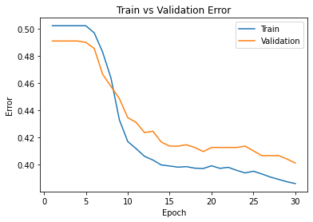

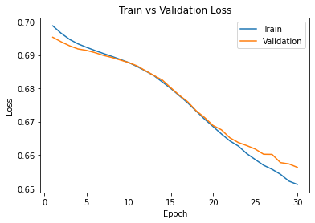

```python
model_path = get_model_name("DropNet", batch_size=128, learning_rate=0.001, epoch=29)
plot_training_curve(model_path)
```

```python
train_net(norm_net, batch_size=128, learning_rate=0.001, num_epochs=30)
```

```
Files already downloaded and verified
Files already downloaded and verified
Epoch 1: Train err: 0.50225, Train loss: 0.6944983942168099 |Validation err: 0.4905, Validation loss: 0.6920223124325275
Epoch 2: Train err: 0.497125, Train loss: 0.6920673676899501 |Validation err: 0.477, Validation loss: 0.690337035804987
Epoch 3: Train err: 0.46925, Train loss: 0.6898699724485003 |Validation err: 0.4585, Validation loss: 0.6887927539646626
Epoch 4: Train err: 0.44275, Train loss: 0.6879004410334996 |Validation err: 0.4425, Validation loss: 0.6870637238025665
Epoch 5: Train err: 0.428375, Train loss: 0.6859667074112665 |Validation err: 0.434, Validation loss: 0.68574258685112
Epoch 6: Train err: 0.417375, Train loss: 0.6840652813987126 |Validation err: 0.427, Validation loss: 0.6840948611497879
Epoch 7: Train err: 0.4085, Train loss: 0.6819634314567323 |Validation err: 0.4245, Validation loss: 0.6821125969290733
Epoch 8: Train err: 0.404625, Train loss: 0.6798374775856261 |Validation err: 0.415, Validation loss: 0.6802428886294365
Epoch 9: Train err: 0.40575, Train loss: 0.6776331823969645 |Validation err: 0.4135, Validation loss: 0.6782665476202965
Epoch 10: Train err: 0.404125, Train loss: 0.675591061985682 |Validation err: 0.4135, Validation loss: 0.67685841396451
Epoch 11: Train err: 0.403875, Train loss: 0.6730485047612872 |Validation err: 0.4125, Validation loss: 0.6752104945480824
Epoch 12: Train err: 0.40175, Train loss: 0.6707799538733468 |Validation err: 0.408, Validation loss: 0.6728724390268326
Epoch 13: Train err: 0.397875, Train loss: 0.6689834878558204 |Validation err: 0.4085, Validation loss: 0.6710931845009327
Epoch 14: Train err: 0.397375, Train loss: 0.6663193693236699 |Validation err: 0.4055, Validation loss: 0.6706914603710175
Epoch 15: Train err: 0.394625, Train loss: 0.6643285940563868 |Validation err: 0.404, Validation loss: 0.6675882004201412
Epoch 16: Train err: 0.3925, Train loss: 0.6622744467523363 |Validation err: 0.4, Validation loss: 0.6663647629320621
Epoch 17: Train err: 0.390875, Train loss: 0.660543147533659 |Validation err: 0.3985, Validation loss: 0.6648768447339535
Epoch 18: Train err: 0.386125, Train loss: 0.6585172197175404 |Validation err: 0.399, Validation loss: 0.6630744822323322
Epoch 19: Train err: 0.38475, Train loss: 0.6564537759811159 |Validation err: 0.3985, Validation loss: 0.662340022623539
Epoch 20: Train err: 0.383, Train loss: 0.654760824309455 |Validation err: 0.4, Validation loss: 0.6605538576841354
Epoch 21: Train err: 0.380375, Train loss: 0.6528454290495979 |Validation err: 0.4, Validation loss: 0.6600035987794399
Epoch 22: Train err: 0.37775, Train loss: 0.6508794758054945 |Validation err: 0.397, Validation loss: 0.6581398956477642
Epoch 23: Train err: 0.374125, Train loss: 0.6494376006580534 |Validation err: 0.395, Validation loss: 0.6568372622132301
Epoch 24: Train err: 0.37225, Train loss: 0.6465663966678438 |Validation err: 0.398, Validation loss: 0.6563714630901814
Epoch 25: Train err: 0.37275, Train loss: 0.6445811873390561 |Validation err: 0.3975, Validation loss: 0.6554624699056149
Epoch 26: Train err: 0.368625, Train loss: 0.6421822214883471 |Validation err: 0.3945, Validation loss: 0.6536009348928928
Epoch 27: Train err: 0.366, Train loss: 0.6404930485619439 |Validation err: 0.3925, Validation loss: 0.6539545990526676
Epoch 28: Train err: 0.362125, Train loss: 0.6383216116163466 |Validation err: 0.387, Validation loss: 0.651848915964365
Epoch 29: Train err: 0.361, Train loss: 0.6358144671197922 |Validation err: 0.388, Validation loss: 0.6513552144169807
Epoch 30: Train err: 0.356125, Train loss: 0.6342583251377892 |Validation err: 0.383, Validation loss: 0.6505867503583431
Finished Training
Total time elapsed: 65.35 seconds
```

```python
evaluate(norm_net, test_loader ,  criterion = nn.BCEWithLogitsLoss())
# The error and loss do not make sense even if the graphs did make sense and do not show an error of 1.
# I tried running this multiple times with different dropout rates and learning rates.
```

```
(1.0, nan)
```

[figure not shown]

[figure not shown]

```python
model_path = get_model_name("Normalization", batch_size=128, learning_rate=0.001, epoch=29)
plot_training_curve(model_path)
```

## Part B.7-Conceptual Questions [6 pt]

### Part B.7.a - [3 pt]

Explain the difference between L1 and L2 regularization and when it is appropriate to use one over the other. How would you implement L1 regularization in simpleANN?

```python
# The difference between L1 and L2 regularization is the type of function
#   - L1 norm:
#       - constant gradient (vanishing gradient possibility --> difficulty for training and back prop if feature are correlated)
#       - promotes sparsity of the solution, i.e., shrinks model paramters to zeros
#       - L1 regularization is used when features have low correlation
#       - Reduces model complexity
#       - Robust to outliers
#       - Penalizes the sum of absolute values of the weights

#   - L2 norm:
#     - Non - constant gradient therefore forces weights to small values but not zero
#     - Non - sparse solution
#     - Not robust to outliers
#     - Penalizes the sum of squares of the weights diffrence.


# For a simple ANN , we would add the L1 regularization term in the objective function we wish to minimize
```

### Part B.7.b - [3 pt]

Describe the impact of different activation functions (e.g. ReLU, Sigmoid, Tanh) on the performance of the model. How would you go about choosing the appropriate activation function for simpleANN?

```python
#  - ReLU:
#     - convergs quickly and thus takes much less time compared to Sigmoid and Tanh due to its infinite gradient at the origin
#     - improves model performance yet is prone to overfitting with inadequate hyperparameters.
#     - Does not activate all neurons at the same time.
#     - Gradient around the origin can be tricky
#     - Con: Mapps all negative values to 0

#  - Sigmoid:
#     - Used when we are expecting a probability of an output
#     - Gradient saturates and vanishes for very large positive and negative values (is data is not normalized)
#     - Used for backprop to optimize weights.
#     - Along with softmax, Sigmoid is used for multiclass classification

#  - Tanh:
#     - Similar to sigmoid, issue with vanishing gradients for very positive and very negative values of x
#     - Typically used for binary classification

#   For a simple ANN, the choice of activation function would depend on the nature of the problem (binary vs multiclass classification)
#   It would also depend on the type of the data, and the expected output.
#   Different functions can be tested and the choice of activation function would depend on the convergence of the loss function
```

### Saving to HTML

Detailed instructions for saving to HTML can be found [here](https://stackoverflow.com/questions/53460051/convert-ipynb-notebook-to-html-in-google-colab/64487858#64487858). Provided below are a summary of the instructions:

(1) download your ipynb file by clicking on File->Download.ipynb

(2) reupload your file to the temporary Google Colab storage (you can access the temporary storage from the tab to the left)

(3) run the following:

```python
%%shell
jupyter nbconvert --to html LAB_1_ANN_and_PyTorch.ipynb
```

```
[NbConvertApp] Converting notebook LAB_1_ANN_and_PyTorch.ipynb to html
[NbConvertApp] Writing 1148117 bytes to LAB_1_ANN_and_PyTorch.html
```

(4) the html file will be available for download in the temporary Google Colab storage

(5) review the html file and make sure all the results are visible before submitting your assignment to Quercus